Let us consider the dataframe birthwt, which contains data on 189 births at the Baystate Medical Centre, Springfield, Massachusetts during 1986. The focus is on the variables listed below

The aim of the study is to analyze the potential relationship between the response variable bwt and the explanatory variables age and race. Describe how to perform a preliminary data analysis on this dataframe using suitable R commands and comment the following plots

### EDA

```r
source("./../functions.R", local = knitr::knit_global())

str(birthwt)
```

```
## 'data.frame':    189 obs. of  10 variables:
##  $ low  : int  0 0 0 0 0 0 0 0 0 0 ...
##  $ age  : int  19 33 20 21 18 21 22 17 29 26 ...
##  $ lwt  : int  182 155 105 108 107 124 118 103 123 113 ...
##  $ race : int  2 3 1 1 1 3 1 3 1 1 ...
##  $ smoke: int  0 0 1 1 1 0 0 0 1 1 ...
##  $ ptl  : int  0 0 0 0 0 0 0 0 0 0 ...
##  $ ht   : int  0 0 0 0 0 0 0 0 0 0 ...
##  $ ui   : int  1 0 0 1 1 0 0 0 0 0 ...
##  $ ftv  : int  0 3 1 2 0 0 1 1 1 0 ...
##  $ bwt  : int  2523 2551 2557 2594 2600 2622 2637 2637 2663 2665 ...
```

```r
birthwt$low = factor(birthwt$low)
birthwt$race = factor(birthwt$race, labels = c("white", "black", "other"))
birthwt$smoke = factor(birthwt$smoke)
birthwt$ptl = factor(birthwt$ptl)
birthwt$ht = factor(birthwt$ht)
birthwt$ui = factor(birthwt$ui)
birthwt$ftv = factor(birthwt$ftv)

summary(birthwt)
```

```
##  low          age             lwt           race    smoke   ptl     ht
##  0:130   Min.   :14.00   Min.   : 80.0   white:96   0:115   0:159   0:177
##  1: 59   1st Qu.:19.00   1st Qu.:110.0   black:26   1: 74   1: 24   1: 12
##          Median :23.00   Median :121.0   other:67           2:  5
##          Mean   :23.24   Mean   :129.8                      3:  1
##          3rd Qu.:26.00   3rd Qu.:140.0
##          Max.   :45.00   Max.   :250.0
##  ui      ftv          bwt
##  0:161   0:100   Min.   : 709
##  1: 28   1: 47   1st Qu.:2414
##          2: 30   Median :2977
##          3:  7   Mean   :2945
##          4:  4   3rd Qu.:3487
##          6:  1   Max.   :4990
```

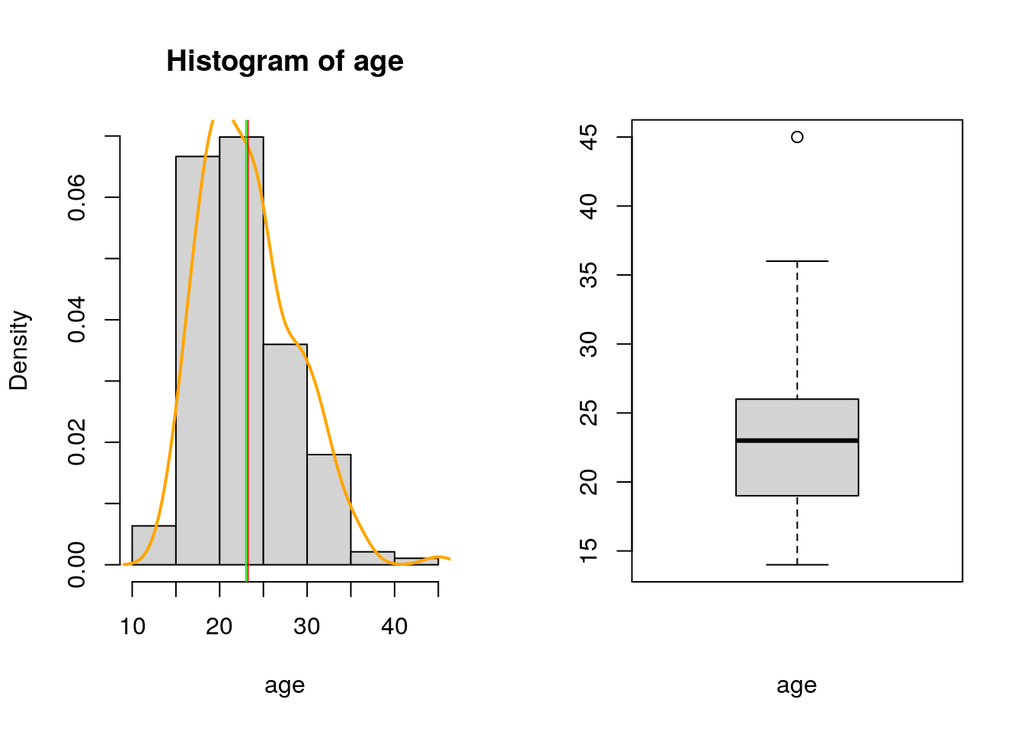

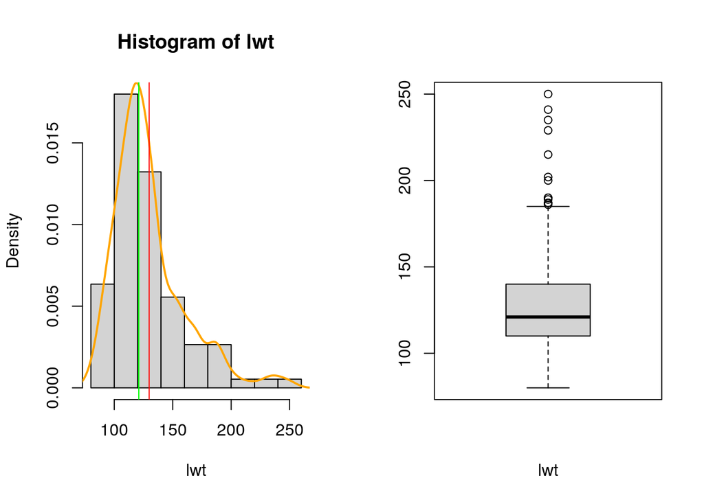

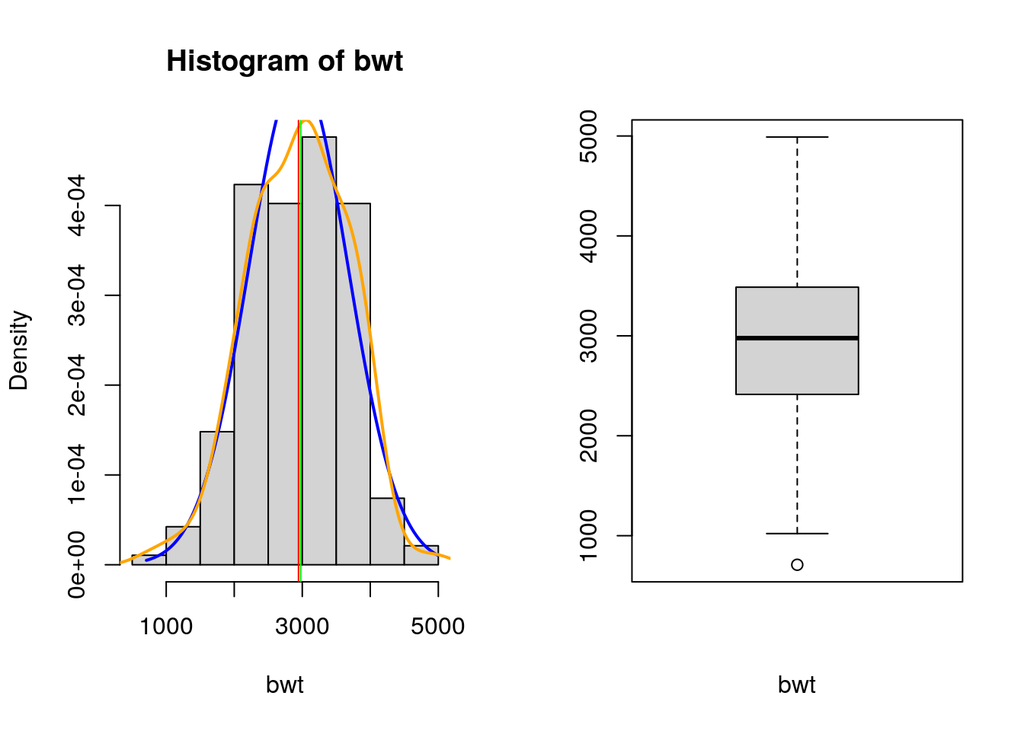

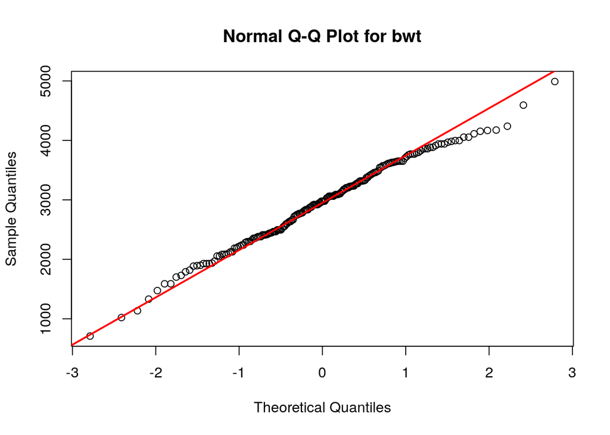

```
## [1] "Skewness indexes"
##        age        lwt        bwt
##  0.7164391  1.3908551 -0.2069775
## [1] "Kurtosis indexes - 3"
##        age        lwt        bwt
##  0.5684420  2.3091809 -0.1132162
```

```r
numeric.graph(birthwt, variables = c(2,3,10), qqplot = 10)
```

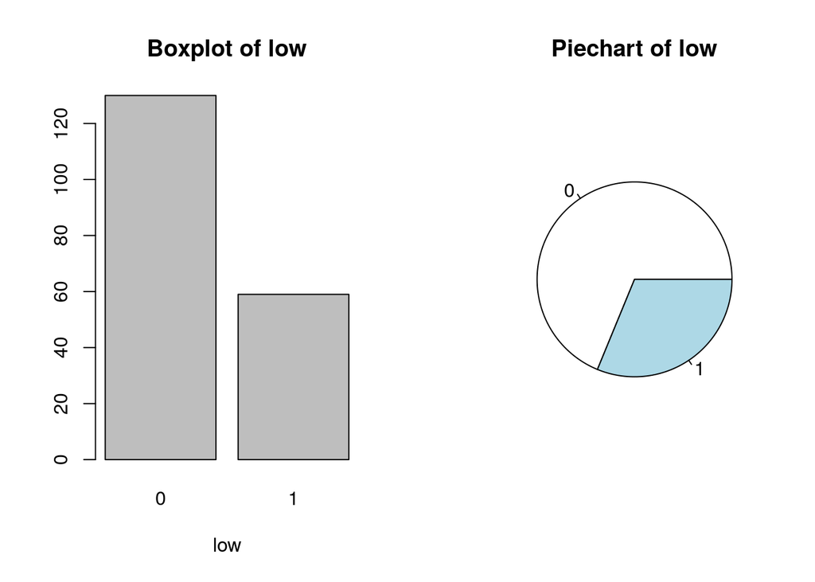

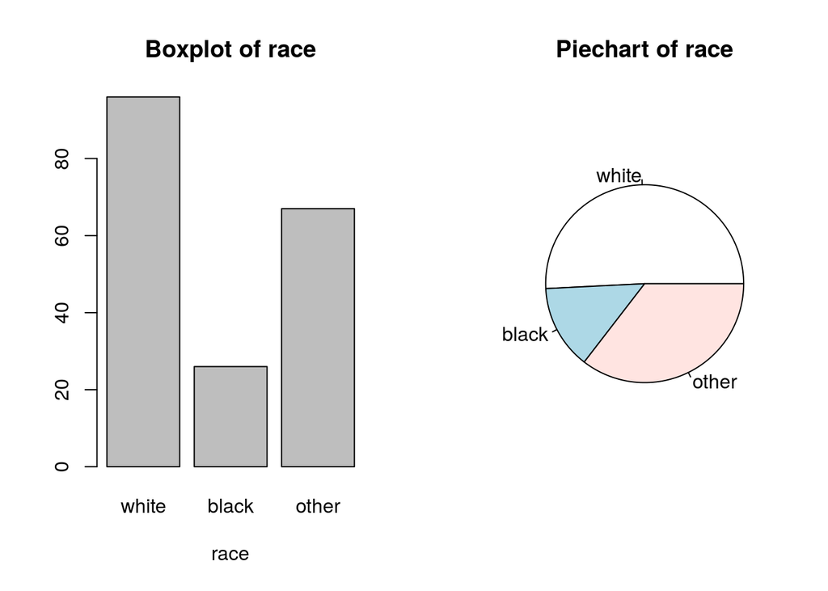

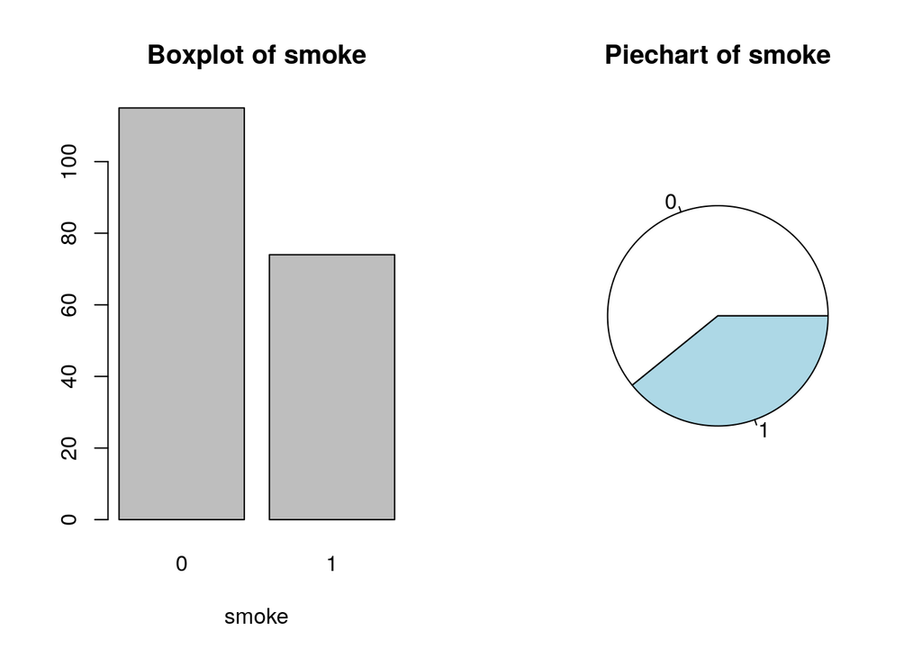

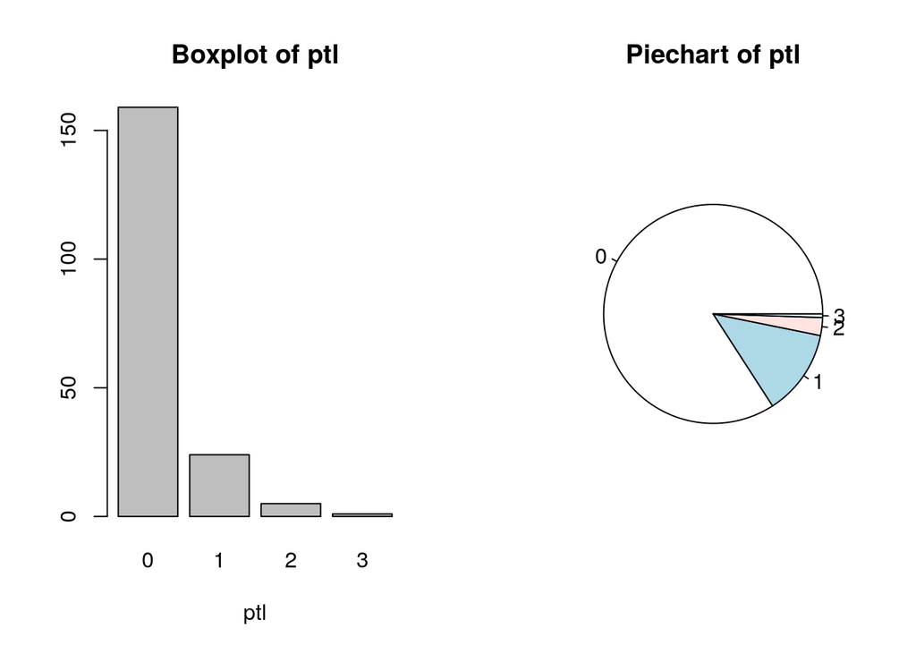

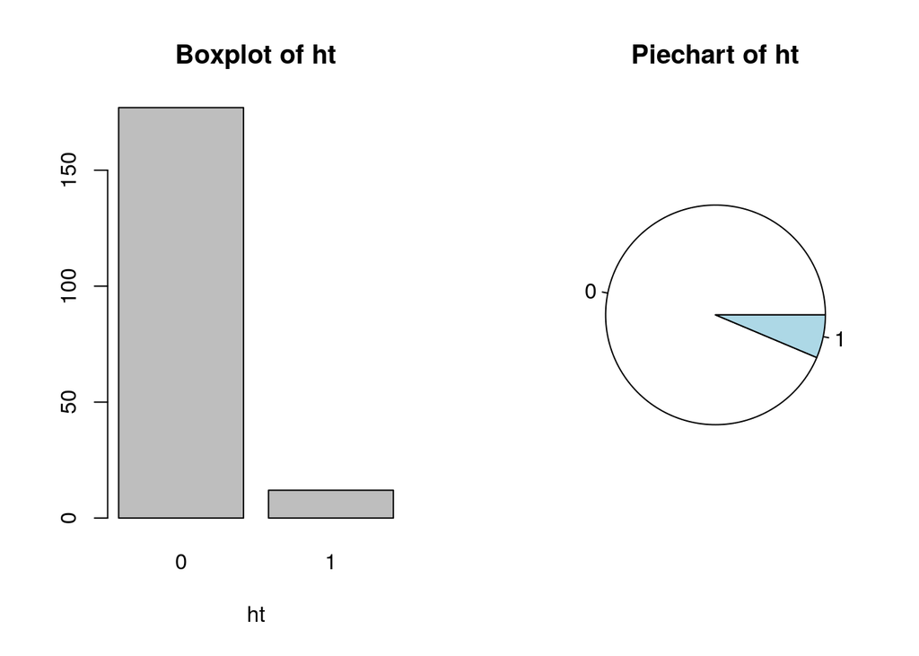

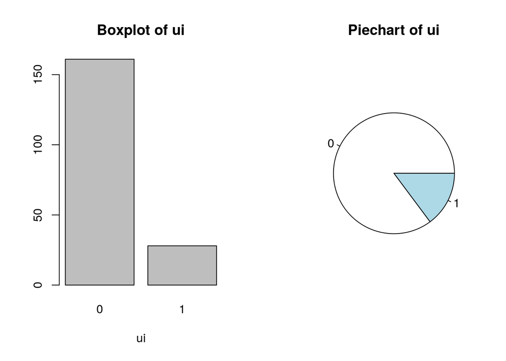

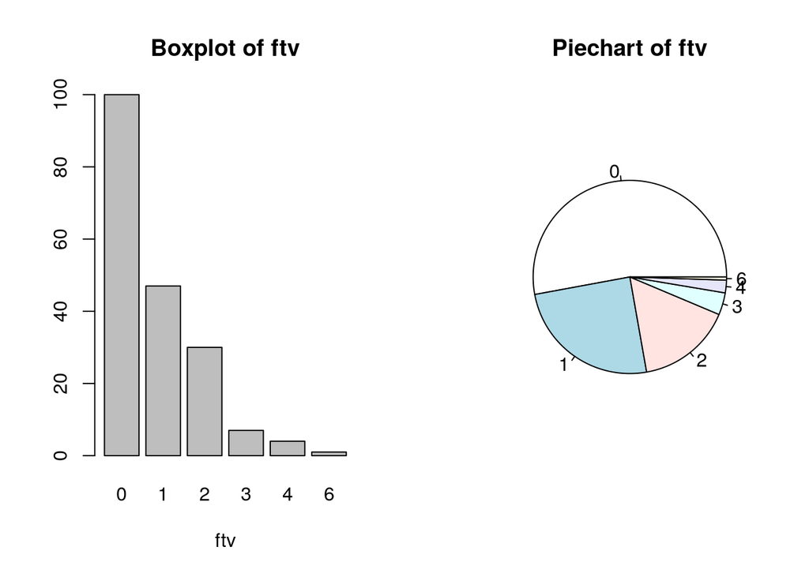

```r
categorical.graph(birthwt, c(1,4:9))
```

La variabile risposta ha una curva a campana molto simile a una normale (come visibile sia dalla curva di densità che dal qqplot, oltre che da simmetria e curtosi).

I grafici di `ptl` e `ftv` assomigliano a quelli di una distribuzione geometrica.

I grafici di `ht`, `ui` e `race` mostrano la presenza di fattori con poche osservazioni sul totale, mentre per `smoke` e `low` i due fattori sono distribuiti abbastanza equamente tra le osservazioni.

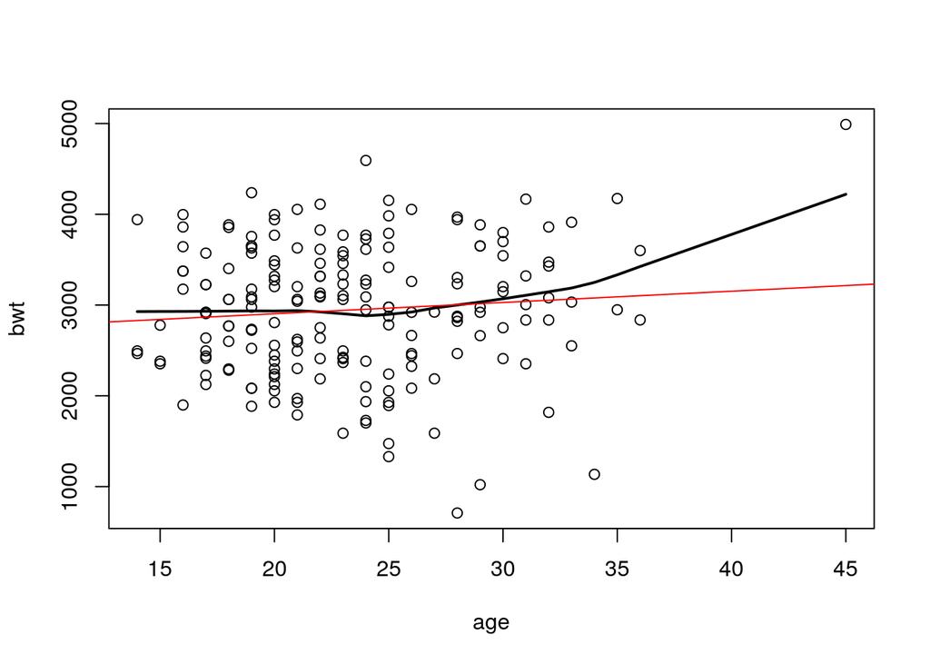

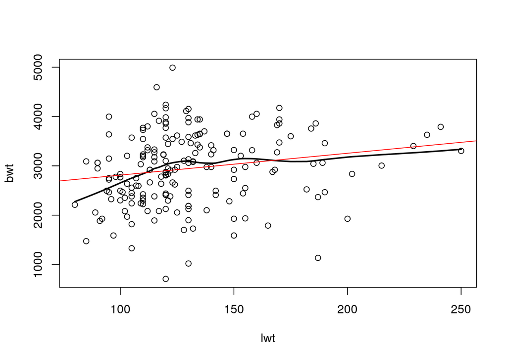

```r
scatterplots.graph(response.var = 10, esplicative.vars = c(2,3), data = birthwt)
```

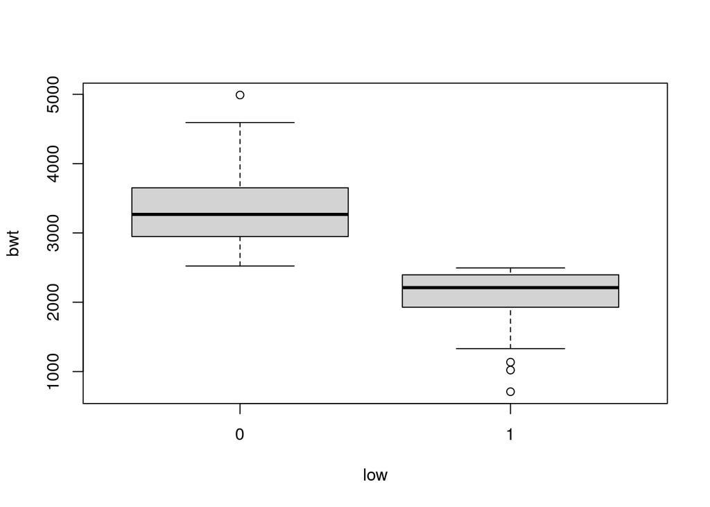

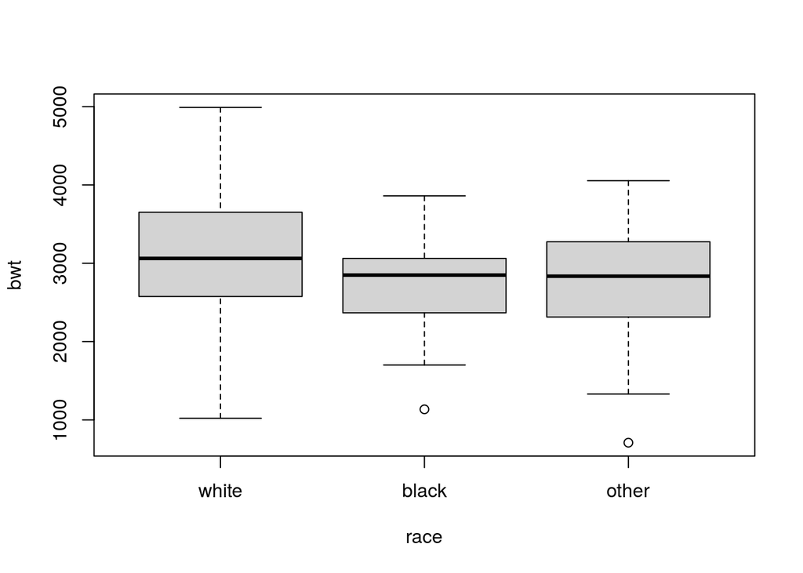

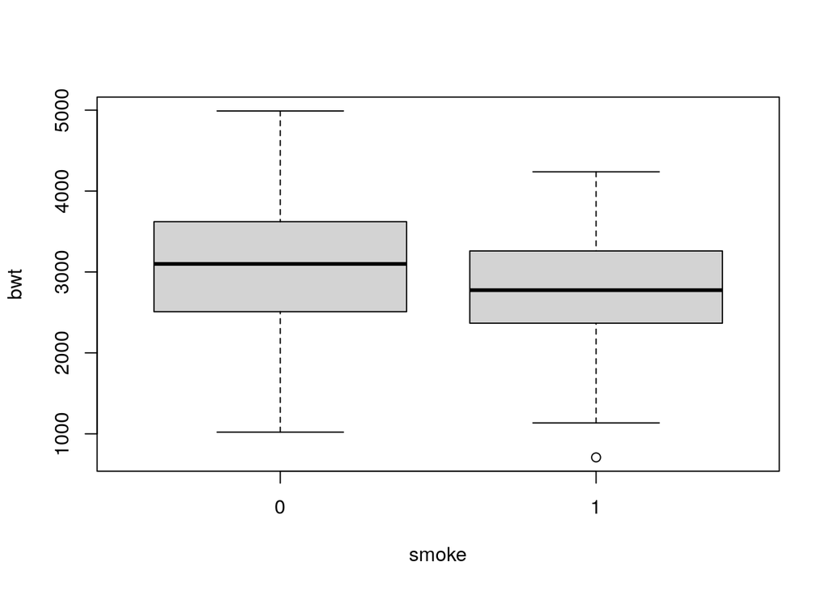

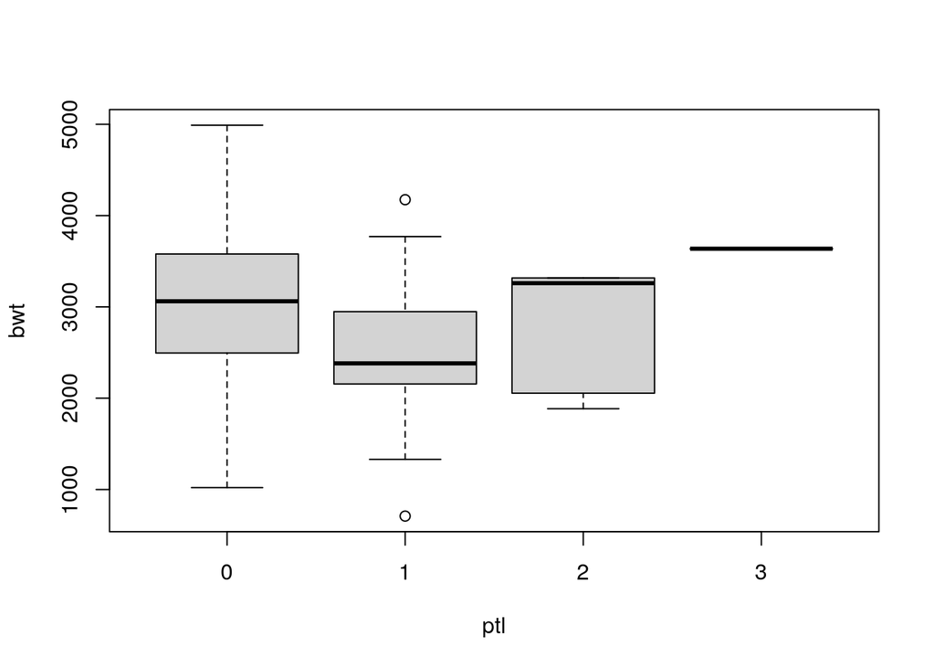

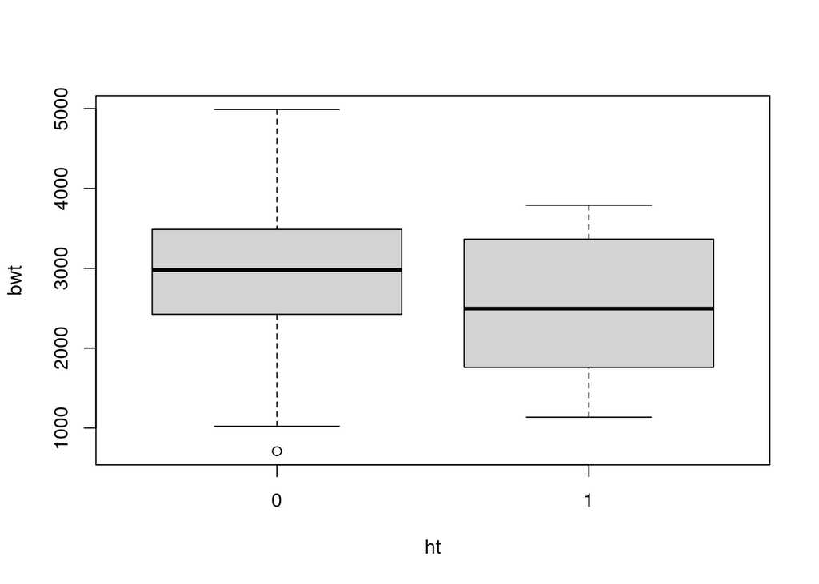

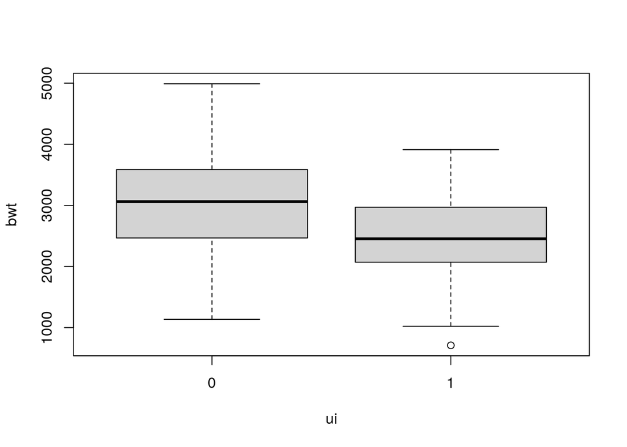

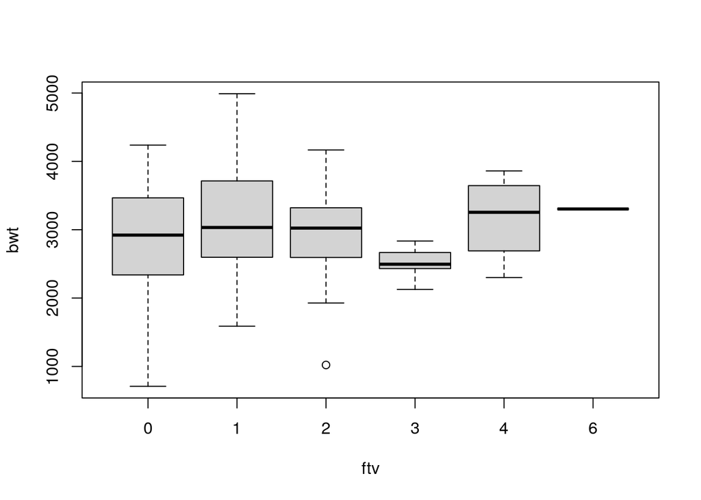

```r
boxplots.graph(response.var = 10, esplicative.vars = c(1,4:9), data = birthwt)
```

```r
with(data = birthwt, cor(bwt, age, method = "pearson"))
```

```
## [1] 0.09031781
```

```r
with(data = birthwt, cor(bwt, lwt, method = "spearman"))
```

```
## [1] 0.2488882
```

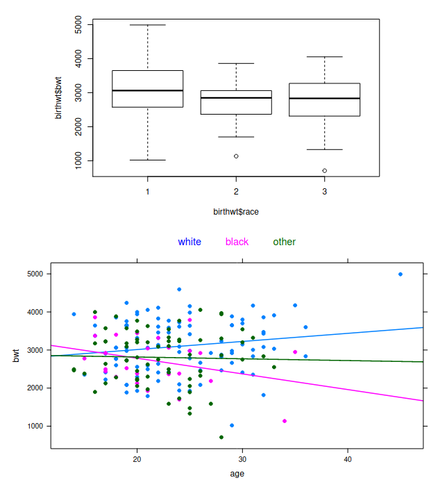

Il secondo grafico rappresenta lo scatterplot tra `bwt` ed `age`, con i punti raggruppati in base al valore di `race` e per ogni gruppo è stata tracciata la retta di regressione.

In order to describe the potential relationship between birth weight and age, taking into account also the factor race, we compare the following nested models

```r
bwt.lm1 <- lm(bwt ~ 1 , data = birthwt)
bwt.lm2 <- lm(bwt ~ age, data = birthwt)
bwt.lm3 <- lm(bwt ~ race + age, data = birthwt)
bwt.lm4 <- lm(bwt ~ race * age, data = birthwt)
```

Describe the four models and comment the results given by the Analysis of Variance Table, reported below. Moreover, propose some alternative model selection procedures.

```r
anova(bwt.lm1, bwt.lm2, bwt.lm3, bwt.lm4)
```

```
## Analysis of Variance Table
##
## Model 1: bwt ~ 1
## Model 2: bwt ~ age
## Model 3: bwt ~ race + age
## Model 4: bwt ~ race * age
##   Res.Df      RSS Df Sum of Sq      F  Pr(>F)
## 1    188 99969656
## 2    187 99154173  1    815483 1.6145 0.20547
## 3    185 94754346  2   4399826 4.3555 0.01419 *
## 4    183 92431148  2   2323199 2.2998 0.10317
## ---
## Signif. codes:  0 '***' 0.001 '**' 0.01 '*' 0.05 '.' 0.1 ' ' 1
```

```r
# Come comportarsi in questi casi?
# Cosa mettere prima?

anova(lm(bwt ~ age*race, data = birthwt))
```

```
## Analysis of Variance Table
##
## Response: bwt
##            Df   Sum Sq Mean Sq F value  Pr(>F)
## age         1   815483  815483  1.6145 0.20547
## race        2  4399826 2199913  4.3555 0.01419 *
## age:race    2  2323199 1161599  2.2998 0.10317
## Residuals 183 92431148  505088
## ---
## Signif. codes:  0 '***' 0.001 '**' 0.01 '*' 0.05 '.' 0.1 ' ' 1
```

```r
anova(lm(bwt ~ race*age, data = birthwt))
```

```
## Analysis of Variance Table
##
## Response: bwt
##            Df   Sum Sq Mean Sq F value   Pr(>F)
## race        2  5015725 2507863  4.9652 0.007945 **
## age         1   199584  199584  0.3951 0.530390
## race:age    2  2323199 1161599  2.2998 0.103171
## Residuals 183 92431148  505088
## ---
## Signif. codes:  0 '***' 0.001 '**' 0.01 '*' 0.05 '.' 0.1 ' ' 1
```

Let us consider Model 3 and comment the output obtained by the R functions summary and plot.

```
##
## Call:
## lm(formula = bwt ~ race + age, data = birthwt)
##
## Residuals:
##      Min       1Q   Median       3Q      Max
## -2131.57  -488.02    -1.16   521.87  1757.07
##
## Coefficients:
##             Estimate Std. Error t value Pr(>|t|)
## (Intercept) 2949.979    255.352  11.553   <2e-16 ***
## raceblack   -365.715    160.636  -2.277   0.0240 *
## raceother   -285.466    115.531  -2.471   0.0144 *
## age            6.288     10.073   0.624   0.5332
## ---
## Signif. codes:  0 '***' 0.001 '**' 0.01 '*' 0.05 '.' 0.1 ' ' 1
##
## Residual standard error: 715.7 on 185 degrees of freedom
## Multiple R-squared:  0.05217,    Adjusted R-squared:  0.0368
## F-statistic: 3.394 on 3 and 185 DF,  p-value: 0.01909
```

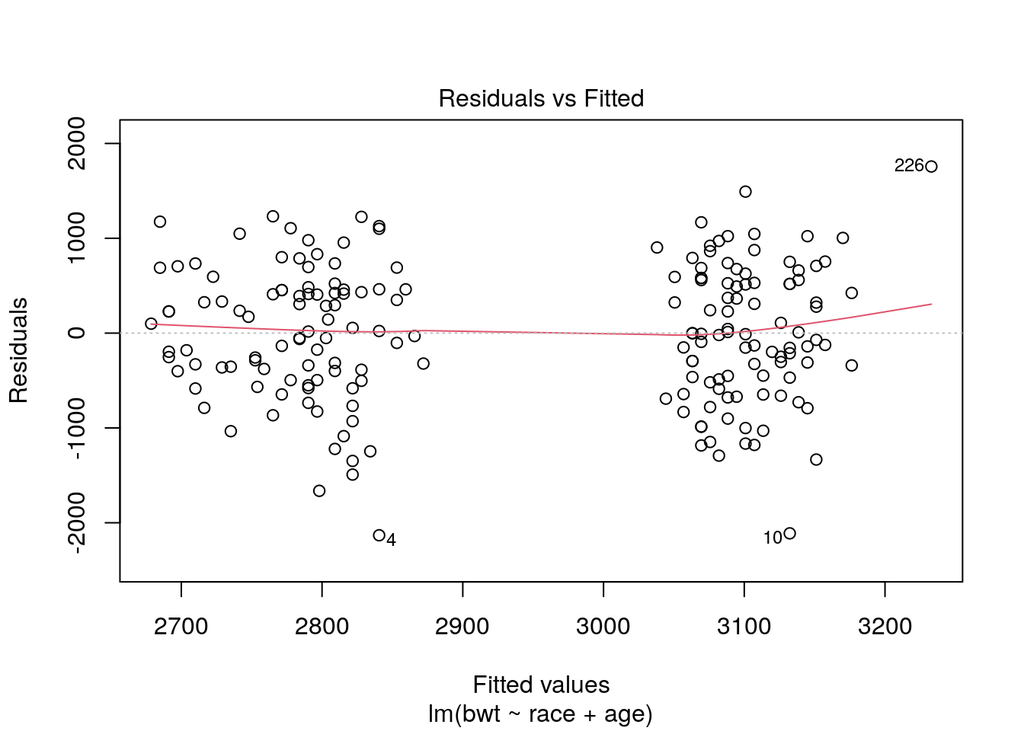

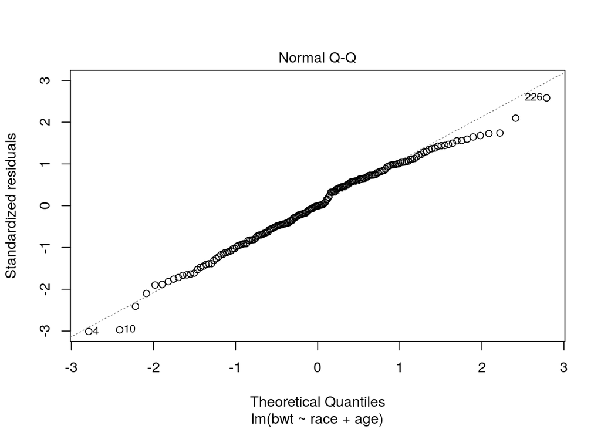

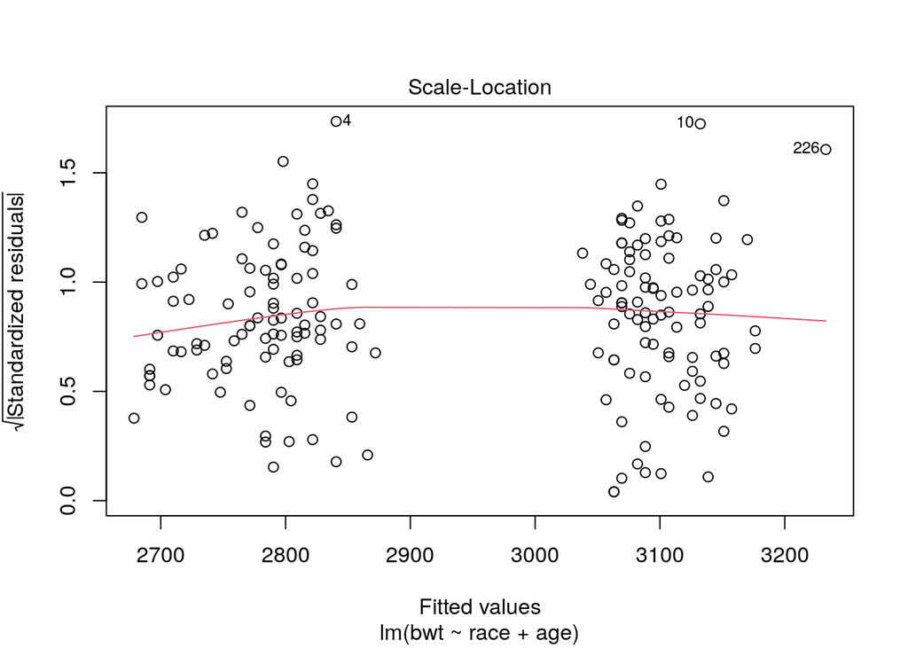

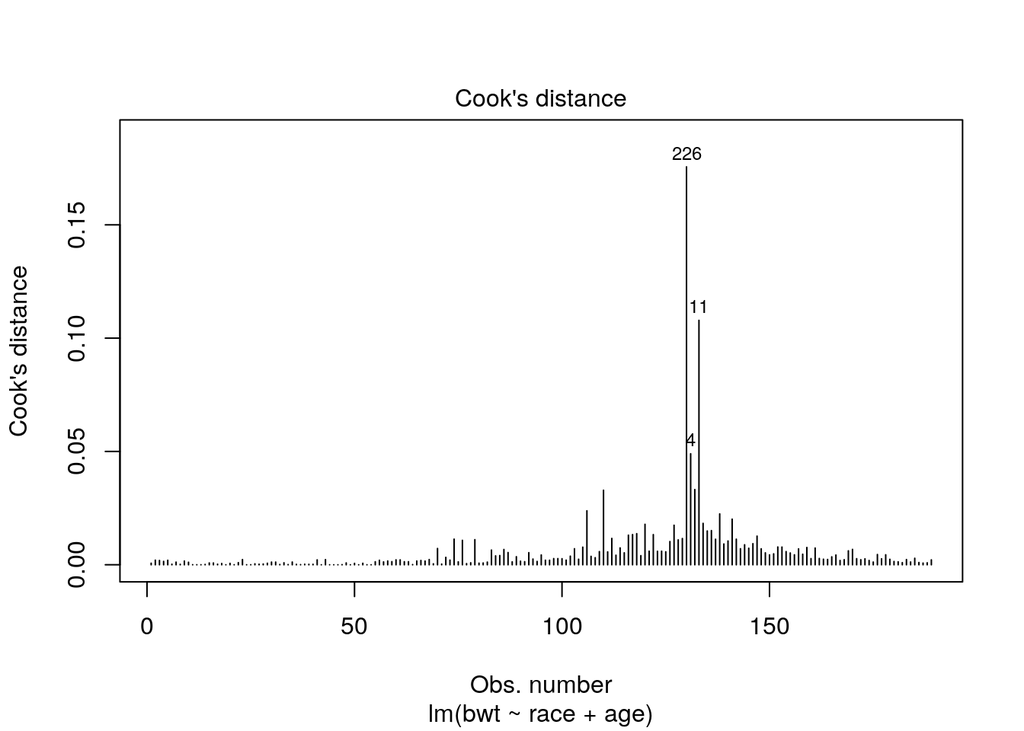

Il modello con solo gli effetti principali rispetta le ipotesi di linearità, omoschedasticità e normalità dei residui.

Si segnalano 3 osservazioni particolarmente influenti nel modello.

Si nota un particolare effetto di clusterizzazione dei fitted values in due gruppi distinti.

Finally, discuss the following graphical output and then suggest how to proceed with further analyses.

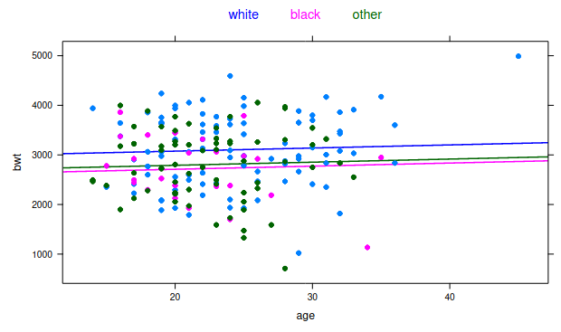

Questo è lo scatterplot del modello di cui sopra. Avendo inserito solo gli effetti principali nel modello, le tre rette sono parallele.

Da questo grafico sono visibili i due cluster individuati nei grafici diagnostici: il cluster a sinistra sono i fitted values con fattore `race`= “black” o “other”, il cluster più a destra sono i fitted values con valore `race`=“white”.

Proviamo a scegliere il modello migliore per il dataset. Cerchiamo i regressori più significativi:

```r
drop1(lm(bwt~., data=birthwt), test="F")
```

```
## Single term deletions
##
## Model:
## bwt ~ low + age + lwt + race + smoke + ptl + ht + ui + ftv
##        Df Sum of Sq      RSS    AIC  F value    Pr(>F)
## <none>              32816695 2314.2
## low     1  38103137 70919832 2457.9 199.7075 < 2.2e-16 ***
## age     1    291381 33108075 2313.9   1.5272  0.218219
## lwt     1    310309 33127004 2314.0   1.6264  0.203921
## race    2   1521490 34338184 2318.8   3.9872  0.020291 *
## smoke   1    860319 33677014 2317.1   4.5091  0.035144 *
## ptl     3    502670 33319364 2311.1   0.8782  0.453609
## ht      1    352130 33168824 2314.2   1.8456  0.176076
## ui      1   2515733 35332427 2326.2  13.1855  0.000372 ***
## ftv     5    149482 32966177 2305.1   0.1567  0.977762
## ---
## Signif. codes:  0 '***' 0.001 '**' 0.01 '*' 0.05 '.' 0.1 ' ' 1
```

I 4 regressori più significativi sono `low`, `rage`, `smoke` e `ui`.

```r
bwt.lm5 <- lm(bwt~low + smoke + race + ui, data = birthwt)
summary(bwt.lm5)
```

```
##
## Call:
## lm(formula = bwt ~ low + smoke + race + ui, data = birthwt)
##
## Residuals:
##      Min       1Q   Median       3Q      Max
## -1039.37  -338.51    30.49   298.19  1489.19
##
## Coefficients:
##             Estimate Std. Error t value Pr(>|t|)
## (Intercept)  3500.81      58.71  59.624  < 2e-16 ***
## low1        -1131.17      71.33 -15.857  < 2e-16 ***
## smoke1       -157.30      70.29  -2.238 0.026442 *
## raceblack    -206.36      97.38  -2.119 0.035434 *
## raceother    -189.89      74.74  -2.541 0.011898 *
## ui1          -309.28      90.04  -3.435 0.000734 ***
## ---
## Signif. codes:  0 '***' 0.001 '**' 0.01 '*' 0.05 '.' 0.1 ' ' 1
##
## Residual standard error: 432 on 183 degrees of freedom
## Multiple R-squared:  0.6584, Adjusted R-squared:  0.6491
## F-statistic: 70.55 on 5 and 183 DF,  p-value: < 2.2e-16
```

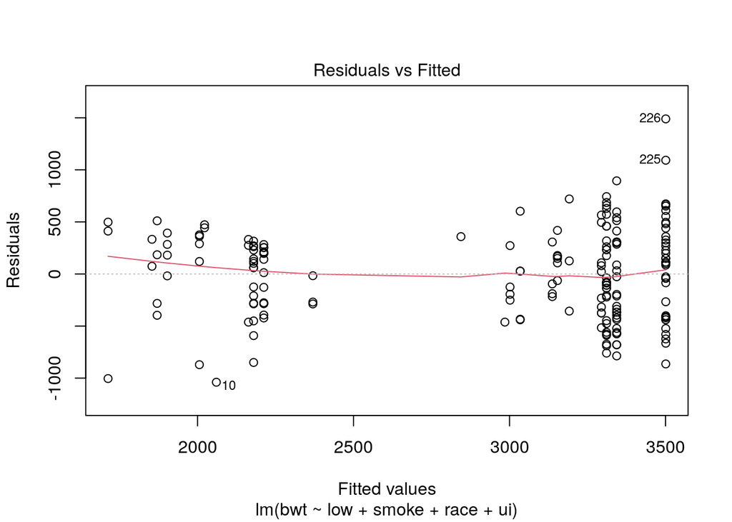

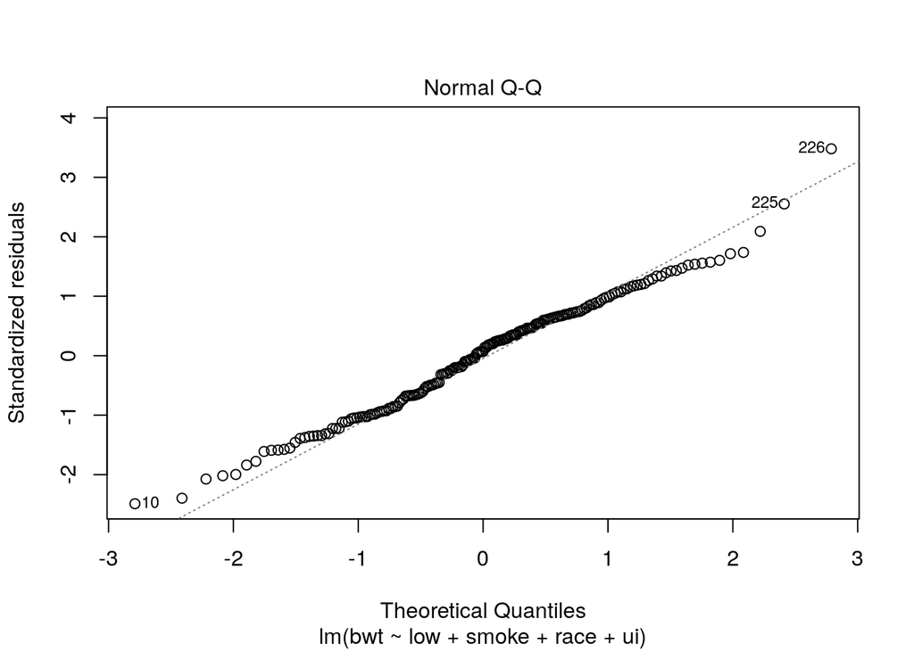

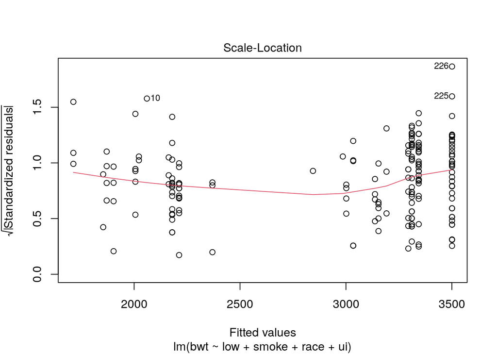

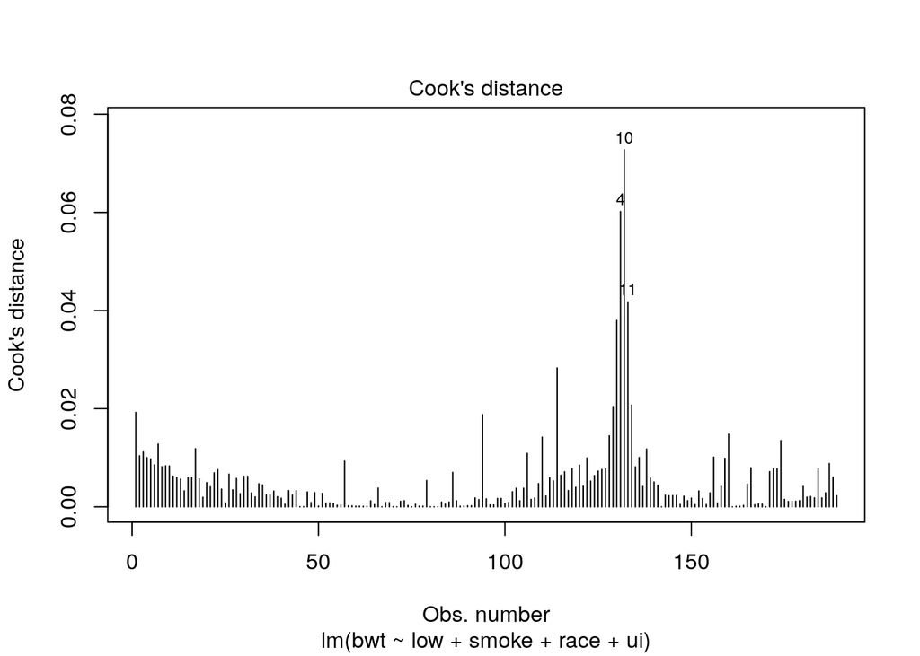

```r
plot(bwt.lm5, which=1:4)
```

Il nuovo modello rispetta le ipotesi di linearità e omoschedasticità, l’ipotesi di normalità dei residui è parzialmente rispettata, infatti la linea dei residui standardizzati si discosta dai quantili teorici sulle code e centralmente, ma non in maniera esagerata. Non ci sono punti particolarmente influenti (la massima distanza di Cook è <0.08).